# Даша!

[figure not shown]

Я тебя очень-очень люблю!

[figure not shown]

Ты

красивая,

[figure not shown]

талантливая,

[figure not shown]

живая и жизнерадостная,

[figure not shown]

просто секс,

[figure not shown]

страстная,

[figure not shown]

умная,

[figure not shown]

спортивная,

[figure not shown]

иногда странная,

[figure not shown]

но такая вдохновляющая,

[figure not shown]

девушка-загадка ...

[figure not shown]

... и Королева!

[figure not shown]

И много-много что еще

заботливая, привлекательная, добрая, нежная, милая, очаровательная, обворожительная, неповторимая, неописуемая, незабываемая, неотразимая, шикарная, ослепительная, страстная, недоступная, божественная, завораживающая, лучезарная, яркая , пушистая, обалденная, сногсшибательная, стройная, обольстительная, кокетливая, утончённая, грациозная, весёлая, энергичная, креативная, стильная, коммуникабельная, тактичная, романтичная ...

...разносторонняя, сказочная, симпатичная, пылкая, единственная, ласковая, сладенькая, умопомрачительная, желанная, непредсказуемая, цветущая, безупречная, гармоничная, отзывчивая, совершенная, лучшая, скромная, изысканная, шаловливая, отпадная, искренняя, дружелюбная, понимающая, экстравагантная, мечтательная, ароматная, искромётная, чистолюбивая, манящая, восторженная, бескорыстная, соблазнительная, одурманивающая, жизнерадостная, прелестная, улыбчивая...

...зажигательная, честная, возбуждающая, чистосердечная, игривая, обаятельная, непредсказуемая, целеустремлённая, дивная, женственная, бесподобная, лучезарная, ненаглядная, необходимая, изумительная, сказочная, трогательная, любимая, самая-самая!

Ах да, еще юмор :Р

### Еще тебя очень любят

Показать кто

А один так вообще --- не может устоять перед твоим обаянием

[figure not shown]

*А помнишь все наши совместные фотографии?*

А помнишь как я сделал игру в подарок, а ты завидовала?

Ну я не мог оставить и тебя на др без игры! Проверим, помнишь ли ты)

Показать ответ

**2016-06-18 21:36:03**

[figure not shown]

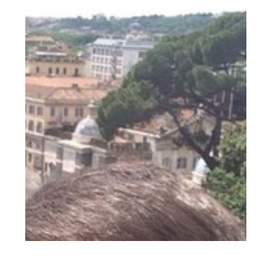

```python
plot_face(0, photo_links, photo_dates, 'we')
```

Я тебе желаю огромный

[figure not shown]

огромный

[figure not shown]

огромный-преогромный

[figure not shown]

кусок мохнатого счастья!

[figure not shown]

И чтобы все-все было хорошо, все мечты сбывались бы, все ладилось, ты не болела, радовалась и радовала, не грустила, высыпалась, вкусно и сытно кушала, купалась в море, любила и наслаждалась бы тем, что я тебя люблю.

[figure not shown]

## C Днем Рождения, любимая!

```python
YouTubeVideo('U4jfkfmcQ9s')
```

[video not shown]

P.S. Продолжение игры, новый уровень сложности - фотографии с тобой (>400 штук!):

Показать ответ

**2013-02-18 23:59:35**

[figure not shown]

[figure not shown]

```python
plot_face(np.random.randint(len(photo_links2)), photo_links2, photo_dates2, 'you')
```